# Question2

To connect to this MongoDB, you need to either on the campus network or connect via UCDavis VPN.

In this question, do not download more than enough resources from the server. Let the server to do all the calculations if possible. (Limit the results to the first 10 rows if necessary.)

Each document in the `sales` collection represents a single sale from a store run by the supply company. Each document contains the item(s) purchased, information on the customer who made the purchase, and several other details regarding the sale.

```r
library(tidyverse)
library(mongolite)

m <- mongo("sales", db = "data", url = "mongodb://mongouser:secret@alan.ucdavis.edu/data")
```

Hint: to handle the items, you will need to use a `$unwind` stage in `aggregate`.

The following unwinds the `items` array for a particular customer .

```r
m$aggregate('[
  {"$match": {"customer.email": "cauho@witwuta.sv"}},
  {"$unwind": "$items"}
]')
```

[output not shown]

The following gives a list of items for each transaction.

```r
m$aggregate('[
  {"$unwind": "$items"},
  {"$group": {
    "_id": "$_id",
    "items": {"$addToSet" : "$items.name"},
    "purchaseMethod": {"$first": "$purchaseMethod"}
    }
  },
  {"$project": {"_id": false}},
  {"$limit": 10}
]')
```

[output not shown]

##### (a) Find the number of items in each transaction.

```r
m$aggregate('[
  {"$unwind": "$items"},
  {"$group": {
    "_id": "$_id",
    "item number": { "$sum": "$items.quantity" }
    }
  },
  {"$limit": 10}
]')
```

```
##                         _id item number
## 1  5bd761deae323e45a93ce2e5           9
## 2  5bd761deae323e45a93ce2e4          19
## 3  5bd761deae323e45a93ce2e3          25
## 4  5bd761deae323e45a93ce2e2          12
## 5  5bd761deae323e45a93ce2e1          37
## 6  5bd761deae323e45a93ce2e0          37
## 7  5bd761deae323e45a93ce2df          21
## 8  5bd761deae323e45a93ce2de           3
## 9  5bd761deae323e45a93ce1ff           4
## 10 5bd761deae323e45a93ce1fe          25
```

##### (b) Find the amount of money spent in each transaction. (Don’t forget multiple the `quantity` of each item)

```r
m$aggregate('[
  {"$unwind": "$items"},
  {"$project": {"_id":1, "amount":{"$multiply":["$items.price", "$items.quantity"]}}},
  {"$group": {
    "_id": "$_id",
    "total_amount": { "$sum": "$amount" }
    }
  },
  {"$limit": 10}
]')
```

```
##                         _id total_amount
## 1  5bd761deae323e45a93ce2e5       317.95
## 2  5bd761deae323e45a93ce2e4      5736.57
## 3  5bd761deae323e45a93ce2e3      5904.47
## 4  5bd761deae323e45a93ce2e2       394.87
## 5  5bd761deae323e45a93ce2e1       791.95
## 6  5bd761deae323e45a93ce2e0      2278.50
## 7  5bd761deae323e45a93ce2df       539.93
## 8  5bd761deae323e45a93ce2de        29.37
## 9  5bd761deae323e45a93ce1ff        44.04
## 10 5bd761deae323e45a93ce1fe       582.94
```

##### (c) Compute each customer satisfaction and plot it against the transction amount (you could reuse the result from (b)).

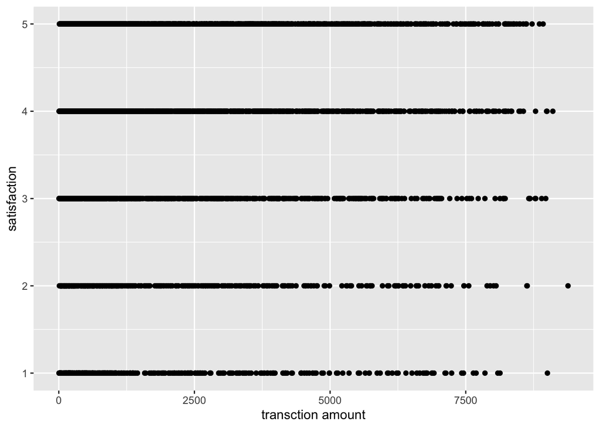

```r
m$aggregate('[
  {"$unwind": "$items"},
  {
    "$project": {"_id":1,
    "amount":{"$multiply":["$items.price", "$items.quantity"]},
     "customer.satisfaction":1}},
  {"$group": {
    "_id": {
      "id":"$_id",
      "satisfaction":"$customer.satisfaction"
    },
    "total_amount": { "$sum": "$amount" }
    }
  }
]') %>%   mutate(satisfaction = `_id`$satisfaction, `_id` = NULL) %>%
  ggplot(aes(x=total_amount, y=satisfaction)) + geom_point() +
  labs(x="transction amount")
```

```r
m$aggregate('[
  {"$group": {
    "_id": "$storeLocation",
    "num": { "$sum": 1 }
    }
  }
]')
```

```
##         _id  num
## 1 San Diego  346
## 2   Seattle 1134
## 3    Denver 1549
## 4    London  794
## 5  New York  501
## 6    Austin  676
```

##### (e) How many notepad were sold in total?

```r
m$aggregate('[
  {"$unwind": "$items"},
  {"$match": {"items.name":"notepad"}},
  {"$group": {
    "_id": null,
    "num": { "$sum": "$items.quantity" }
    }
  },
  {"$project":{"_id":0}}
]')
```

```
##     num
## 1 20727
```